# R para análisis de datos de encuestas: reestructura y agregación

Felipe Gonzalez

July 31, 2014

## 1. Complejidad de cuestionarios para encuestas

Las estructuras de datos producidas por cuestionarios en encuestas son muchas veces de las más complejas a las que un analista de datos se pude enfrentar.

Esta complejidad, en buena parte, resulta de la lógica de la conversación del cuestionario y del deseo de explorar con detalle algunas respuestas. Así, hay algunas preguntas para desempleados, por ejemplo, y otras para gente que tiene trabajo. A su vez, quizá el conjunto de preguntas de un oficinista son distintas a las de un obrero, y así sucesivamente.

En la siguiente figura, por ejemplo, cada cuadrado representa una pregunta, y las aristas representan posibles saltos dentro de el cuestionario que dependen de las respuestas del entrevistado (es el cuestionario de la Labor Force Survey de Austrialia en 2004, tomado de [Samuel Spencer](https://docs.google.com/file/d/0B8B3UT7DvOCOYlYxbEp4N0ZuQnc/edit)):

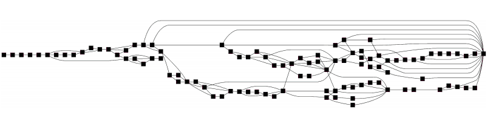

Este es un ejemplo típico de un cuestionario largo.

Esta complejidad de datos producidos por cuestionarios en realidad no tiene límite: describir el flujo de un cuestionario requiere un lenguaje de programación general, y entonces un cuestionario en teoría puede producir datos tan complejos como un programa general de computadora.

Otra fuente de complejidad es la heterogeneidad de tipos de variables que se recogen en un cuestionario típo: existen respuestas numéricas, categóricas, proporciones que suman uno, matrices (qué bebidas toma en cada momento del día), y listas generales (por ejemplo, listar las bebidas que hoy me he tomado). Conocer técnicas adecuadas para procesar cada tipo de variable ayuda mucho en el análisis.

En lo que sigue no nos enfocamos en técnicas simplemente *correctas* para procesar estos datos. Más bien nos interesan técnicas que sean correctas, pero también robustas (a errores típicos), rápidas, y que requieran poco *overhead* intelectual. Es mejor reservar nuestro pensamiento para cosas más fundamentales como decidir qué análisis hacer o qué variables considerar en qué análisis.

## ¿Qué necesitamos para hacer análisis de datos?

Podemos separar en tres partes el total de técnicas y tareas del análisis de datos:

1. **Limpieza y reestructura de datos**: estas técnicas nos permiten preparar de forma apropiada datos para análisis o visualización.
2. **Fundamentales de análisis**: esto es propiamente dicho el análisis, que consiste en
- Filtrar (seleccionar partes de los datos),
- Agrupar (separar en grupos para procesar cada grupo por separado y contrastar) y
- Agregar (resumir un conjunto de datos para entender algunos de sus aspectos).
3. **Visualización**: presentar datos en gráficas.

Las herramientas básicsa que utilizaremos están en los paquetes *dplyr* y *tidyr*.

```r
library(dplyr)
library(tidyr)
```

# 2. Tablas de datos

Los datos de encuestas generalmente están vertidos en una sola tabla, con observaciones (personas) en los renglones y preguntas en las columnas.

Veamos un ejemplo simple. Primero leemos la tabla de un archivo separado por comas:

```r
colores <- read.csv(file = 'encuesta_colores.csv')
colores
```

```
##   folio   sexo color.favorito
## 1     1 hombre           azul
## 2     2 hombre          negro
## 3     3  mujer           azul
## 4     4  mujer          negro
## 5     5  mujer          verde
## 6     6  mujer          negro
## 7     7 hombre          verde
## 8     8  mujer          negro
```

Tiene tres columnas: *folio*, que es un indentificador de la persona, *sexo* de la persona encuestada, *color.favorito*, la respuesta de la persona a la pregunta de cuál es su color favorito. Podemos calcular el tamaño de la tabla:

```r
dim(colores)
```

```
## [1] 8 3
```

```r
nrow(colores)
```

```
## [1] 8
```

La tabla *colores* es un **data.frame**, que es la estructura de datos de R para tablas de datos heterogéneos (numéricos, caracteres, etc.)

```r
class(colores)
```

```
## [1] "data.frame"
```

Podemos ver una parte de la tabla usando *head* y *tail*

```r
head(colores, 3) ## primeros tres renglones
```

```
##   folio   sexo color.favorito
## 1     1 hombre           azul
## 2     2 hombre          negro
## 3     3  mujer           azul
```

```r
tail(colores, 3) ## últimos tres renglones
```

```
##   folio   sexo color.favorito
## 6     6  mujer          negro
## 7     7 hombre          verde
## 8     8  mujer          negro
```

Ahora veamos un ejemplo más realista En el siguiente ejemplo preguntamos a 38 personas acerca de su uso de algunos servicios y sitios de internet.

| id | edad | sexo | uso_wikipedia | uso_facebook | uso_twitter | uso_youtube | uso_amazon | frecuencia_wikipedia | frecuencia_facebook | frecuencia_twitter | frecuencia_youtube | frecuencia_amazon | amigos_wikipedia | amigos_facebook | amigos_twitter | amigos_youtube | amigos_amazon |
| --- | --- | --- | --- | --- | --- | --- | --- | --- | --- | --- | --- | --- | --- | --- | --- | --- | --- |
| 46264669 | 23 | Femenino | si | si | si | si | si | Más de una vez al día | Más de una vez al día | Una vez por semana | Dos o tres veces a la semana | Una vez al mes o menos | Muchos de mis amigos y conocidos usan . | Muchos de mis amigos y conocidos usan . | Tengo pocos amigos o conocidos que usen . | Muchos de mis amigos y conocidos usan . | Algunos de mis amigos y conocidos usan . |
| 46332648 | 22 | Femenino | si | si | no | no | no | Una vez por semana | Una vez al día |  |  |  | Muchos de mis amigos y conocidos usan . | La mayoría usa . |  |  |  |
| 46336027 | 21 | Masculino | si | no | no | si | no | Una vez por semana |  |  | Una vez al mes o menos |  | Muchos de mis amigos y conocidos usan . |  |  | Muchos de mis amigos y conocidos usan . |  |
| 46350666 | 19 | Femenino | si | si | no | si | no | Una vez por semana | Más de una vez al día |  | Una vez al mes o menos |  | La mayoría usa . | La mayoría usa . |  | Muchos de mis amigos y conocidos usan . |  |
| 46383860 | 20 | Masculino | si | no | no | si | no | Una vez al mes o menos |  |  | Una vez por semana |  | Muchos de mis amigos y conocidos usan . |  |  | La mayoría usa . |  |
| 46390121 | 20 | Femenino | si | si | no | si | no | Una vez por semana | Una vez por semana |  | Dos o tres veces a la semana |  | Muchos de mis amigos y conocidos usan . | La mayoría usa . |  | La mayoría usa . |  |

Esta tabla tiene un total de 38 renglones (que corresponden a 38 personas), y 18 columnas, que corresponden a distintas preguntas. La primera columna **id** es un identificador único de la persona encuestada, luego viene registrada su edad y sexo. Las últimas columnas agrupan las respuestas a tres preguntas:

- Si usó o no wikipedia, facebook, twitter, youtube y amazon en el último mes
- La frecuencia con que visita los sitios que visitó en el último mes.
- Según su percepción, que tanto amigos y conocidos usan los sitios que visitó el último mes.

Los datos están en un archivo separado por comas, y podemos leerlo y ver las primeras tres líneas de la siguiente forma. Ojo: esta tabla es considerablemente ancha, así que los renglones están partidos en varios bloques. Podemos ver el número de renglón a la izquierda, seguido de los dos gatos ##:

```r
encuesta <- read.csv(file = 'simple_encuesta.csv')
head(encuesta, 3)
```

```
##         id edad      sexo uso_wikipedia uso_facebook uso_twitter
## 1 46264669   23  Femenino            si           si          si
## 2 46332648   22  Femenino            si           si          no
## 3 46336027   21 Masculino            si           no          no
##   uso_youtube uso_amazon  frecuencia_wikipedia   frecuencia_facebook
## 1          si         si Más de una vez al día Más de una vez al día
## 2          no         no    Una vez por semana        Una vez al día
## 3          si         no    Una vez por semana
##   frecuencia_twitter           frecuencia_youtube      frecuencia_amazon
## 1 Una vez por semana Dos o tres veces a la semana Una vez al mes o menos
## 2
## 3                          Una vez al mes o menos
##                          amigos_wikipedia
## 1 Muchos de mis amigos y conocidos usan .
## 2 Muchos de mis amigos y conocidos usan .
## 3 Muchos de mis amigos y conocidos usan .
##                           amigos_facebook
## 1 Muchos de mis amigos y conocidos usan .
## 2                        La mayoría usa .
## 3
##                              amigos_twitter
## 1 Tengo pocos amigos o conocidos que usen .
## 2
## 3
##                            amigos_youtube
## 1 Muchos de mis amigos y conocidos usan .
## 2
## 3 Muchos de mis amigos y conocidos usan .
##                              amigos_amazon
## 1 Algunos de mis amigos y conocidos usan .
## 2
## 3
```

Podemos ver el tamaño de la tabla con (renglones x columnas):

```r
dim(encuesta)
```

```
## [1] 38 18
```

# 3. Selección de variables

Con filtros y selección de variables aislamos partes de los datos para analizar por separado.

En nuestro ejemplo anterior, por ejemplo, nos interesa comenzar por analizar las variables edad y sexo y uso de twitter. Podemos extraer estas variables haciendo

```r
encuesta.sub <- encuesta %>% select(id, edad, sexo, uso_twitter)
head(encuesta.sub)
```

```
##         id edad      sexo uso_twitter
## 1 46264669   23  Femenino          si
## 2 46332648   22  Femenino          no
## 3 46336027   21 Masculino          no
## 4 46350666   19  Femenino          no
## 5 46383860   20 Masculino          no
## 6 46390121   20  Femenino          no
```

Podemos hacer esa extracción dando rangos de variables en la tabla. Por ejemplo, para seleccionar todas las columnas de id a sexo, inclusive, y además uso_twitter, hacemos:

```r
encuesta.sub <- encuesta %>% select(id:sexo, uso_twitter)
head(encuesta.sub)
```

```
##         id edad      sexo uso_twitter
## 1 46264669   23  Femenino          si
## 2 46332648   22  Femenino          no
## 3 46336027   21 Masculino          no
## 4 46350666   19  Femenino          no
## 5 46383860   20 Masculino          no
## 6 46390121   20  Femenino          no
```

# 3. Filtros

Con filtros seleccionamos los renglones de la tabla que nos interesa analizar. Por ejemplo, en la tabla anterior tenemos hombres y mujeres:

```r
 encuesta.sub
```

```
##          id edad      sexo uso_twitter
## 1  46264669   23  Femenino          si
## 2  46332648   22  Femenino          no
## 3  46336027   21 Masculino          no
## 4  46350666   19  Femenino          no
## 5  46383860   20 Masculino          no
## 6  46390121   20  Femenino          no
## 7  46390124   21  Femenino          no
## 8  46391237   20 Masculino          no
## 9  46404114   22  Femenino          no
## 10 46404911   19  Femenino          no
## 11 46405704   23  Femenino          si
## 12 46406298   27  Femenino          si
## 13 46408821   23 Masculino          no
## 14 46413725   22 Masculino          no
```

[output cut: 24 more lines]

para obtener una tabla que solo contenga a los hombres, hacemos

```r
encuesta.masc <- encuesta.sub %>% filter(sexo=='Masculino')
```

y obtenemos

```r
encuesta.masc
```

```
##          id edad      sexo uso_twitter
## 1  46336027   21 Masculino          no
## 2  46383860   20 Masculino          no
## 3  46391237   20 Masculino          no
## 4  46408821   23 Masculino          no
## 5  46413725   22 Masculino          no
## 6  46426046   21 Masculino          no
## 7  46491981   22 Masculino          no
## 8  46495209   20 Masculino          si
## 9  46515440   22 Masculino          no
## 10 46543190   21 Masculino          no
## 11 46546922   21 Masculino          no
## 12 46547342   20 Masculino          no
## 13 46556310   20 Masculino          no
## 14 46607487   21 Masculino          no
## 15 46619196   22 Masculino          si
## 16 46626355   23 Masculino          no
## 17 46645824   63 Masculino          no
## 18 46668610   37 Masculino          si
## 19 46673556   21 Masculino          no
## 20 46677661   20 Masculino          no
```

Y si además queremos a los hombres de menos de 21 años, podemos poner las dos condiciones separadas por comas:

```r
encuesta.masc.21 <- encuesta.sub %>% filter(sexo=='Masculino', edad < 21)
```

```r
encuesta.masc.21
```

```
##         id edad      sexo uso_twitter
## 1 46383860   20 Masculino          no
## 2 46391237   20 Masculino          no
## 3 46495209   20 Masculino          si
## 4 46547342   20 Masculino          no
## 5 46556310   20 Masculino          no
## 6 46677661   20 Masculino          no
```

que es una tabla con datos de 6 personas.

Podemos encadenar estas transformaciones con el operador %>%, que se llama operador *tubo* (¿por qué?). Por ejemplo, para seleccionar de la tabla original todos los hombres de menos de 21 años, y solamente las columnas sexo, edad y usa_facebook, haríamos:

```r
datos <- encuesta %>%
   select(sexo, edad, uso_facebook) %>%
   filter(sexo=='Masculino', edad < 21)
```

y vemos por ejemplo que solamente 3 de estos hombres de menos de 21 años usa Facebook:

```r
datos
```

```
##        sexo edad uso_facebook
## 1 Masculino   20           no
## 2 Masculino   20           no
## 3 Masculino   20           si
## 4 Masculino   20           si
## 5 Masculino   20           si
## 6 Masculino   20           no
```

# 4. Agrupación y resumen

Una tarea fundamental del análisis de datos es cortar en distintas partes los datos para aplicar un mismo procedimiento a cada uno de ellos (por ejemplo, para cada ciudad, calcular el ingreso promedio).

Usamos los verbos *group_by* y *summarise* para hacer estos procesos.

Por ejemplo, supongamos que queremos calcular la edad promedio de hombres y de mujeres en nuestra encuesta. Comenzamos con la siguiente tabla donde ya habíamos seleccionado algunas variables:

```r
encuesta.sub
```

```
##          id edad      sexo uso_twitter
## 1  46264669   23  Femenino          si
## 2  46332648   22  Femenino          no
## 3  46336027   21 Masculino          no
## 4  46350666   19  Femenino          no
## 5  46383860   20 Masculino          no
## 6  46390121   20  Femenino          no
## 7  46390124   21  Femenino          no
## 8  46391237   20 Masculino          no
## 9  46404114   22  Femenino          no
## 10 46404911   19  Femenino          no
## 11 46405704   23  Femenino          si
## 12 46406298   27  Femenino          si
## 13 46408821   23 Masculino          no
## 14 46413725   22 Masculino          no
```

[output cut: 24 more lines]

Y agrupamos esta tabla

```r
encuesta.ag <- encuesta.sub %>%
   group_by(sexo)
```

```r
encuesta.ag
```

```
## Source: local data frame [38 x 4]
## Groups: sexo
##
##          id edad      sexo uso_twitter
## 1  46264669   23  Femenino          si
## 2  46332648   22  Femenino          no
## 3  46336027   21 Masculino          no
## 4  46350666   19  Femenino          no
## 5  46383860   20 Masculino          no
## 6  46390121   20  Femenino          no
## 7  46390124   21  Femenino          no
## 8  46391237   20 Masculino          no
## 9  46404114   22  Femenino          no
## 10 46404911   19  Femenino          no
## 11 46405704   23  Femenino          si
```

[output cut: 27 more lines]

Nótese que la única diferencia es que las primeras líneas de esta salida nos indica que ya están formados los grupos según la variable *sexo*. Ahora usamos summarise para resumir:

```r
resumen <- encuesta.sub %>%
   group_by(sexo) %>%
   summarise(edad.promedio = mean(edad))
```

```r
resumen
```

```
## Source: local data frame [2 x 2]
##
##        sexo edad.promedio
## 1  Femenino            22
## 2 Masculino            24
```

```r
resumen <- encuesta.sub %>%
   group_by(sexo, uso_twitter) %>%
   summarise(edad.promedio = mean(edad))
```

```r
resumen
```

```
## Source: local data frame [4 x 3]
## Groups: sexo
##
##        sexo uso_twitter edad.promedio
## 1  Femenino          no         21.57
## 2  Femenino          si         23.50
## 3 Masculino          no         23.59
## 4 Masculino          si         26.33
```

Que nos da la edad promedio para todas las combinaciones de *sexo* y *uso_twitter*.

Ahora supongamos que no solo queremos saber la edad promedio, sino también cuantas personas hay en cada grupo y la desviación estándar de la edad en cada grupo. Número de personas y desviación estándar también son agregados, así que simplemente los agregamos al summarise:

```r
resumen <- encuesta %>%
   group_by(sexo, uso_twitter) %>%
   summarise(edad.promedio = mean(edad), edad.de=sd(edad), n = n() )
resumen
```

```
## Source: local data frame [4 x 5]
## Groups: sexo
##
##        sexo uso_twitter edad.promedio edad.de  n
## 1  Femenino          no         21.57   2.593 14
## 2  Femenino          si         23.50   2.517  4
## 3 Masculino          no         23.59  10.205 17
## 4 Masculino          si         26.33   9.292  3
```

La función *n()* solamente cuenta cuántos renglones hay en cada grupo definido por *group_by*.

Nótese que no es necesario seleccionar las columnas que usamos en la operación: como estas columnas no están ni en *group_by* ni en el *summarise*, son ignoradas en el cálculo.

Ahora queremos resumir una variable cualitativa, por ejemplo: ¿cuántas hombres y cuántas mujeres de la muestra usan facebook? Este cálculo es fácil de hacer:

```r
encuesta %>%
   group_by(sexo, uso_facebook) %>%
   summarise(n = n())
```

```
## Source: local data frame [4 x 3]
## Groups: sexo
##
##        sexo uso_facebook  n
## 1  Femenino           no  1
## 2  Femenino           si 17
## 3 Masculino           no  5
## 4 Masculino           si 15
```

### Ejercicio

1. Compara el promedio de edad entre los que usan twitter y los que no usan twitter.
2. Calcula cuántas mujeres y cuántos hombres usan twitter.
3. Entre las personas que no usan twitter, ¿cuántos usan youtube?

## Añadiendo variables

4. Muchas veces queremos agregar cálculos a nuestras tablas. Usamos el verbo *mutate*.

Por ejemplo, por alguna razón podríamos querer calcular en nuestra tabla *encuesta.sub*

```r
head(encuesta.sub)
```

```
##         id edad      sexo uso_twitter
## 1 46264669   23  Femenino          si
## 2 46332648   22  Femenino          no
## 3 46336027   21 Masculino          no
## 4 46350666   19  Femenino          no
## 5 46383860   20 Masculino          no
## 6 46390121   20  Femenino          no
```

cuántos años por arriba de 18 años tiene cada persona. Agregamos una nueva columna con *mutate*:

```r
datos.temp <- encuesta.sub %>%
   mutate(años.encima.18 = edad - 18)
head(datos.temp)
```

```
##         id edad      sexo uso_twitter años.encima.18
## 1 46264669   23  Femenino          si              5
## 2 46332648   22  Femenino          no              4
## 3 46336027   21 Masculino          no              3
## 4 46350666   19  Femenino          no              1
## 5 46383860   20 Masculino          no              2
## 6 46390121   20  Femenino          no              2
```

Por ejemplo, si queremos crear una variable nueva que sea “usa facebook y también twitter”, comenzamos con la tabla

```r
datos.temp <- encuesta %>%
   select(id, uso_facebook, uso_twitter)
head(datos.temp)
```

```
##         id uso_facebook uso_twitter
## 1 46264669           si          si
## 2 46332648           si          no
## 3 46336027           no          no
## 4 46350666           si          no
## 5 46383860           no          no
## 6 46390121           si          no
```

Agregamos una nueva columna como sigue

```r
datos.nuevos <- datos.temp %>%
   mutate(twitter_facebook = uso_facebook=='si' & uso_twitter=='si')
head(datos.nuevos)
```

```
##         id uso_facebook uso_twitter twitter_facebook
## 1 46264669           si          si             TRUE
## 2 46332648           si          no            FALSE
## 3 46336027           no          no            FALSE
## 4 46350666           si          no            FALSE
## 5 46383860           no          no            FALSE
## 6 46390121           si          no            FALSE
```

Nótese que el & de esta expresión significa la condición lógica “y”. Si quisiéramos hacer una nueva variable que fuera “usa alguno de los dos o los dos”, haríamos

```r
datos.nuevos <-
datos.temp %>%
   mutate(twitter_facebook = uso_facebook=='si' & uso_twitter=='si',
          twitter_o_facebook = uso_facebook=='si' | uso_twitter=='si' )
head(datos.nuevos)
```

```
##         id uso_facebook uso_twitter twitter_facebook twitter_o_facebook
## 1 46264669           si          si             TRUE               TRUE
## 2 46332648           si          no            FALSE               TRUE
## 3 46336027           no          no            FALSE              FALSE
## 4 46350666           si          no            FALSE               TRUE
## 5 46383860           no          no            FALSE              FALSE
## 6 46390121           si          no            FALSE               TRUE
```

Nótese que las expresiones lógicas dan resultados lógicos (TRUE o FALSE). Si queremos convertir a “sí” y “no” podemos usar la función ifelse:

```r
datos.finales <- datos.nuevos %>%
   mutate(tw_fb =  ifelse(twitter_facebook, 'si', 'no'))
head(datos.finales)
```

```
##         id uso_facebook uso_twitter twitter_facebook twitter_o_facebook
## 1 46264669           si          si             TRUE               TRUE
## 2 46332648           si          no            FALSE               TRUE
## 3 46336027           no          no            FALSE              FALSE
## 4 46350666           si          no            FALSE               TRUE
## 5 46383860           no          no            FALSE              FALSE
## 6 46390121           si          no            FALSE               TRUE
##   tw_fb
## 1    si
## 2    no
## 3    no
## 4    no
## 5    no
## 6    no
```

## 6. Añadiendo variables con agregación.

Podemos añadir columnas que resultan de datos agregados. Por ejemplo, si queremos agregar una columna que de el promedio de edad de hombres y de mujeres, podemos agrupar y después usar mutate:

```r
promedios <- encuesta %>%
   select(id, sexo, edad) %>%
   group_by(sexo) %>%
   mutate(edad.promedio = mean(edad) )
promedios
```

```
## Source: local data frame [38 x 4]
## Groups: sexo
##
##          id      sexo edad edad.promedio
## 1  46264669  Femenino   23            22
## 2  46332648  Femenino   22            22
## 3  46336027 Masculino   21            24
## 4  46350666  Femenino   19            22
## 5  46383860 Masculino   20            24
## 6  46390121  Femenino   20            22
## 7  46390124  Femenino   21            22
## 8  46391237 Masculino   20            24
## 9  46404114  Femenino   22            22
## 10 46404911  Femenino   19            22
## 11 46405704  Femenino   23            22
```

[output cut: 27 more lines]

Nótese que antes de hacer el *mutate* hicimos un *group_by*. Esto quiere decir que el promedio se calcula dentro de cada grupo, y después la nueva columna simplemente da el promedio del grupo para cada persona. En la tabla de arriba, la edad prmedio de mujeres es 22 años, y por eso cada mujer tiene como valor en la columna edad.promedio el número 22.

Ahora podemos calcular, por ejemplo la diferencia de edad para cada persona con respecto al promedio de su grupo:

```r
promedios <- encuesta %>%
   select(id, sexo, edad) %>%
   group_by(sexo) %>%
   mutate(edad.promedio = mean(edad), edad.dif = edad - edad.promedio )
promedios
```

```
## Source: local data frame [38 x 5]
## Groups: sexo
##
##          id      sexo edad edad.promedio edad.dif
## 1  46264669  Femenino   23            22        1
## 2  46332648  Femenino   22            22        0
## 3  46336027 Masculino   21            24       -3
## 4  46350666  Femenino   19            22       -3
## 5  46383860 Masculino   20            24       -4
## 6  46390121  Femenino   20            22       -2
## 7  46390124  Femenino   21            22       -1
## 8  46391237 Masculino   20            24       -4
## 9  46404114  Femenino   22            22        0
## 10 46404911  Femenino   19            22       -3
## 11 46405704  Femenino   23            22        1
```

[output cut: 27 more lines]

que podemos hacer en un solo *mutate* con

```r
promedios <- encuesta %>%
   select(id, sexo, edad) %>%
   group_by(sexo) %>%
   mutate(edad.dif = edad - mean(edad))
tail(promedios)
```

```
## Source: local data frame [6 x 4]
## Groups: sexo
##
##          id      sexo edad edad.dif
## 33 46645824 Masculino   63       39
## 34 46660107  Femenino   20       -2
## 35 46668610 Masculino   37       13
## 36 46673423  Femenino   28        6
## 37 46673556 Masculino   21       -3
## 38 46677661 Masculino   20       -4
```

# 7. Unión de tablas

Una operación común también es juntar dos tablas de datos que están relacionadas a través de algunas columnas. Por ejemplo, recordamos nuestro ejemplo:

```r
colores
```

```
##   folio   sexo color.favorito
## 1     1 hombre           azul
## 2     2 hombre          negro
## 3     3  mujer           azul
## 4     4  mujer          negro
## 5     5  mujer          verde
## 6     6  mujer          negro
## 7     7 hombre          verde
## 8     8  mujer          negro
```

Y supongamos que tenemos una tabla más que contiene la ciudad donde vive cada persona:

```r
dat.ciudad
```

```
##   folio ciudad
## 5     5    Mty
## 1     1     DF
## 3     3    Mty
## 4     4     DF
## 8     8     DF
## 2     2    Mty
## 6     6    Mty
## 7     7    Mty
```

Podemos usar la función *inner_join* de las siguientes dos maneras:

```r
dat.juntos <- inner_join(colores, dat.ciudad)
dat.juntos <- colores %>% inner_join(dat.ciudad)
dat.juntos
```

```
##   folio   sexo color.favorito ciudad
## 1     5  mujer          verde    Mty
## 2     1 hombre           azul     DF
## 3     3  mujer           azul    Mty
## 4     4  mujer          negro     DF
## 5     8  mujer          negro     DF
## 6     2 hombre          negro    Mty
## 7     6  mujer          negro    Mty
## 8     7 hombre          verde    Mty
```

La función *inner_join* regresa los renglones del argumento de la izquierda (*colores*) que tienen coincidencia (en este caso la variable *folio*) en la tabla de la derecha (*dat.ciudad*). Se omiten los renglones que no tienen coincidencia, por ejemplo:

```r
dat.ciudad.2 <- dat.ciudad[-3, ]
dat.ciudad.2
```

```
##   folio ciudad
## 5     5    Mty
## 1     1     DF
## 4     4     DF
## 8     8     DF
## 2     2    Mty
## 6     6    Mty
## 7     7    Mty
```

```r
dat.juntos.2 <- colores %>% inner_join(dat.ciudad.2)
dat.juntos.2
```

```
##   folio   sexo color.favorito ciudad
## 1     1 hombre           azul     DF
## 2     2 hombre          negro    Mty
## 3     4  mujer          negro     DF
## 4     5  mujer          verde    Mty
## 5     6  mujer          negro    Mty
## 6     7 hombre          verde    Mty
## 7     8  mujer          negro     DF
```

En contraste, la función *left_join* regresa siempre todos los renglones de la tabla del argumento izquierdo:

```r
dat.juntos.2 <- colores %>% left_join(dat.ciudad.2)
dat.juntos.2
```

```
##   folio   sexo color.favorito ciudad
## 1     1 hombre           azul     DF
## 2     2 hombre          negro    Mty
## 3     3  mujer           azul   <NA>
## 4     4  mujer          negro     DF
## 5     5  mujer          verde    Mty
## 6     6  mujer          negro    Mty
## 7     7 hombre          verde    Mty
## 8     8  mujer          negro     DF
```

Nótese que aparece un *NA* en el folio para el que no había valor de ciudad en la tabla *dat.ciudad*.

La función *left_join* es útil para incluir variables de otro tipo. Supongamos que tenemos una tabla con las poblaciones de distintas ciudades:

```r
ciudad.pob
```

```
##   ciudad pob.millones
## 1     DF        8.851
## 2    Mty        1.136
## 3    Gdl        1.495
```

Podemos pegar estos datos en nuestra tabla anterior

```r
dat.juntos
```

```
##   folio   sexo color.favorito ciudad
## 1     5  mujer          verde    Mty
## 2     1 hombre           azul     DF
## 3     3  mujer           azul    Mty
## 4     4  mujer          negro     DF
## 5     8  mujer          negro     DF
## 6     2 hombre          negro    Mty
## 7     6  mujer          negro    Mty
## 8     7 hombre          verde    Mty
```

de la siguiente forma:

```r
dat.juntos %>% left_join(ciudad.pob)
```

```
##   folio   sexo color.favorito ciudad pob.millones
## 1     5  mujer          verde    Mty        1.136
## 2     1 hombre           azul     DF        8.851
## 3     3  mujer           azul    Mty        1.136
## 4     4  mujer          negro     DF        8.851
## 5     8  mujer          negro     DF        8.851
## 6     2 hombre          negro    Mty        1.136
## 7     6  mujer          negro    Mty        1.136
## 8     7 hombre          verde    Mty        1.136
```

En este caso, la unión de tablas se hace a través de la columna *ciudad*. Tanto en *inner_join* como en *left_join* se ignoran los renglones sin coincidencia de la tabla de la derecha. Por el contrario, para la tabla de la izquierda, *inner_join* ignora los renglones sin coincidencia y *left_join* incluye siempre todos sus renglones.

### Ojo: qué pasa si hay más de una coincidencia?

Cuando hay más de una coincidencia, entonces estas uniones duplican renglones. Por ejemplo, si tenemos la tabla

```r
variedades.color <- data.frame(color.favorito = c('azul','azul','negro','verde'),
                               variedad = c('azul marino','azul claro','negro','verde'))
variedades.color
```

```
##   color.favorito    variedad
## 1           azul azul marino
## 2           azul  azul claro
## 3          negro       negro
## 4          verde       verde
```

Al hacer la unión resulta en

```r
colores %>%
   left_join(variedades.color)
```

```
##    folio   sexo color.favorito    variedad
## 1      1 hombre           azul azul marino
## 2      1 hombre           azul  azul claro
## 3      2 hombre          negro       negro
## 4      3  mujer           azul azul marino
## 5      3  mujer           azul  azul claro
## 6      4  mujer          negro       negro
## 7      5  mujer          verde       verde
## 8      6  mujer          negro       negro
## 9      7 hombre          verde       verde
## 10     8  mujer          negro       negro
```

y vemos que los folios de aquellos que dijeron *azul* como color favorito están duplicados: hay una entrada correspondiente a variedad azul marino y otra a variedad azul claro en cada caso.

Este comportamiento es útil en muchos casos, pero es importante estar atentos cuando esto no es lo que queremos.

# 8. Cálculo de porcentajes

Como es una operación muy frecuente, en esta sección tratamos únicamente con cálculo de porcentajes.

### Preguntas simples (respuesta única)

Con estas técnicas es fácil calcular porcentajes de respuesta para una pregunta dentro de distintos grupos. Por ejemplo, supongamos que queremos calcular, dentro de mujeres y de hombres, que porcentaje usa faceboook. En primer lugar, hacemos una agrupación por sexo (variable de agrupación) y uso_facebook (variable respuesta):

```r
encuesta %>%
   group_by(sexo, uso_facebook) %>%
   summarise(n = n())
```

```
## Source: local data frame [4 x 3]
## Groups: sexo
##
##        sexo uso_facebook  n
## 1  Femenino           no  1
## 2  Femenino           si 17
## 3 Masculino           no  5
## 4 Masculino           si 15
```

Necesitamos ahora agrupar solamente con sexo (variable de agrupación), para calcular el total de hombres y el total de mujeres:

```r
encuesta %>%
   group_by(sexo, uso_facebook) %>%
   summarise(n = n()) %>%
   group_by(sexo) %>%
   mutate(n.subtotal = sum(n))
```

```
## Source: local data frame [4 x 4]
## Groups: sexo
##
##        sexo uso_facebook  n n.subtotal
## 1  Femenino           no  1         18
## 2  Femenino           si 17         18
## 3 Masculino           no  5         20
## 4 Masculino           si 15         20
```

Y finalmente calculamos el porcentaje de hombres y de mujeres que usan facebook dividendo la columna de frecuencias (*n*) entre la columna de *n.subtotal*:

```r
encuesta %>%
   group_by(sexo, uso_facebook) %>%
   summarise(n = n()) %>%
   group_by(sexo) %>%
   mutate(n.subtotal = sum(n)) %>%
   mutate(prop = n/n.subtotal)
```

```
## Source: local data frame [4 x 5]
## Groups: sexo
##
##        sexo uso_facebook  n n.subtotal    prop
## 1  Femenino           no  1         18 0.05556
## 2  Femenino           si 17         18 0.94444
## 3 Masculino           no  5         20 0.25000
## 4 Masculino           si 15         20 0.75000
```

Y obtenemos que 94% de las mujeres de la muestra usa facebook y 75% de los hombres de la muestra usó facebook.

Nótese que el primer *group_by* sirve para calcular los totales de mujeres que usan facebook y no usan y hombres que usan o no facebook. El segundo group_by sirve para calcular el número de hombres y mujeres, y el mutate final calcula el cociente que buscamos.

### Ejercicios

1. Calcula el porcentaje de personas que usaron facebook que también usaron youtube.
2. Repite el cálculo anterior para hombres y para mujeres por separado.
3. Calcula, para hombre y mujeres, que porcentajes usan facebook y twitter, qué porcentaje usa facebook pero no twitter, qué porcentaje usa twitter y no facebook, y qué porcentaje no usa ninguno de los dos.

# 9. Preguntas de respuesta múltiple

En las preguntas de respuesta múltiple, puede haber una o varias respuestas, y este número varía con la persona. Por ejemplo:

- Enlista todas las bebidas que te has tomado hoy.

Por ejemplo, en los siguientes datos mostramos posibles respuestas:

```r
resp.bebidas <- data.frame(persona=c(1,2,3,4,5,6,7,8),
                           bebidas =c('café,agua,agua,refresco','agua,agua,agua',
                           'refresco,agua,refresco', 'jugo,café,refresco,refresco',
                           'café,agua', 'jugo,refresco,agua', 'agua','refresco'))
resp.bebidas
```

```
##   persona                     bebidas
## 1       1     café,agua,agua,refresco
## 2       2              agua,agua,agua
## 3       3      refresco,agua,refresco
## 4       4 jugo,café,refresco,refresco
## 5       5                   café,agua
## 6       6          jugo,refresco,agua
## 7       7                        agua
## 8       8                    refresco
```

¿Cómo se organizan estos datos para el análisis? Claramente la versión mostrada arriba no es muy útil, aunque a veces tenemos que lidiar con esta forma.

Una forma posible es la siguiente, que usualmente se llama la **forma ancha**:

```r
dat.ancha
```

```
##   persona       X1       X2       X3       X4
## 1       1     café     agua     agua refresco
## 2       2     agua     agua     agua
## 3       3 refresco     agua refresco
## 4       4     jugo     café refresco refresco
## 5       5     café     agua
## 6       6     jugo refresco     agua
## 7       7     agua
## 8       8 refresco
```

Esta forma ancha tiene la ventaja de que es popular, y de que un renglón corresponde a una persona. Tiene la desventaja de que es poco eficiente en almacenamiento (hay espacio que se ocupa para respuestas vacías), y no es posible hacer análisis directamente sin hacer procedimientos complejos. En general, **es una forma pésima para el análisis.**

La forma larga, en contraste, se ve como sigue:

```r
dat.larga
```

```
##    persona resp.num   bebida
## 1        1        1     café
## 2        1        2     agua
## 3        1        3     agua
## 4        1        4 refresco
## 5        2        1     agua
## 6        2        2     agua
## 7        2        3     agua
## 8        3        1 refresco
## 9        3        2     agua
## 10       3        3 refresco
## 11       4        1     jugo
## 12       4        2     café
## 13       4        3 refresco
## 14       4        4 refresco
## 15       5        1     café
## 16       5        2     agua
## 17       6        1     jugo
## 18       6        2 refresco
## 19       6        3     agua
## 20       7        1     agua
## 21       8        1 refresco
```

Esta forma larga es eficiente en almacenamiento y más apropiada para el análisis. **Nótese que ahora hay tantos renglones para cada persona como bebidas mencionó tal persona**. Por eso, a algunas personas acostumbradas a trabajar con formas exclusivamente anchas a veces los confunde este esquema.

### De forma ancha a forma larga.

Veamos cómo hacer las transformaciones necesarias para poner los datos en forma larga. Tenemos

```r
dat.ancha
```

```
##   persona       X1       X2       X3       X4
## 1       1     café     agua     agua refresco
## 2       2     agua     agua     agua
## 3       3 refresco     agua refresco
## 4       4     jugo     café refresco refresco
## 5       5     café     agua
## 6       6     jugo refresco     agua
## 7       7     agua
## 8       8 refresco
```

Para pasar de ancha a larga, usaremos funciones del paquete *tidyr*. En primer lugar usamos *gather* para convertir las cuatro respuestas en una sola columna. Simplemente apilamos estas columnas manteniendo los identificadores de persona

```r
dat.larga.1 <-
   dat.ancha %>%
      gather(respuesta, bebida, contains('X'))
dat.larga.1
```

```
##    persona respuesta   bebida
## 1        1        X1     café
## 2        2        X1     agua
## 3        3        X1 refresco
## 4        4        X1     jugo
## 5        5        X1     café
## 6        6        X1     jugo
## 7        7        X1     agua
## 8        8        X1 refresco
## 9        1        X2     agua
## 10       2        X2     agua
## 11       3        X2     agua
## 12       4        X2     café
## 13       5        X2     agua
## 14       6        X2 refresco
```

[output cut: 18 more lines]

Para entender lo que hay dentro de *gather*: Nótese que creamos una nueva variable *respuesta* (el nombre lo ponemos nosotros), que identifica de qué columna se trata. Le ponemos el nombre *bebida* a la columna que contiene las respuestas, y finalmente, pedimos apilar todas las columnas desde *X1* hasta *X4*.

Existen algunos renglones vacíos, pues en la versión ancha había respuestas vacías. Podemos filtrarlas:

```r
dat.larga <-  dat.ancha %>%
      gather(respuesta, bebida, X1:X4) %>%
      filter(bebida != '')
dat.larga
```

```
##    persona respuesta   bebida
## 1        1        X1     café
## 2        2        X1     agua
## 3        3        X1 refresco
## 4        4        X1     jugo
## 5        5        X1     café
## 6        6        X1     jugo
## 7        7        X1     agua
## 8        8        X1 refresco
## 9        1        X2     agua
## 10       2        X2     agua
## 11       3        X2     agua
## 12       4        X2     café
## 13       5        X2     agua
## 14       6        X2 refresco
## 15       1        X3     agua
## 16       2        X3     agua
## 17       3        X3 refresco
## 18       4        X3 refresco
## 19       6        X3     agua
## 20       1        X4 refresco
## 21       4        X4 refresco
```

Finalmente, puede ser buena idea limpiar quitando la *X* de la columna de respuesta. Corregimos esta variable y eliminamos la columna anterior:

```r
library(stringr)
dat.larga <-  dat.ancha %>%
      gather(respuesta, bebida, X1:X4) %>%
      filter(bebida != '') %>%
      mutate(respuesta.num = str_sub(respuesta, 2, 2)) %>%
      select(-respuesta)
dat.larga
```

```
##    persona   bebida respuesta.num
## 1        1     café             1
## 2        2     agua             1
## 3        3 refresco             1
## 4        4     jugo             1
## 5        5     café             1
## 6        6     jugo             1
## 7        7     agua             1
## 8        8 refresco             1
## 9        1     agua             2
## 10       2     agua             2
## 11       3     agua             2
## 12       4     café             2
## 13       5     agua             2
## 14       6 refresco             2
## 15       1     agua             3
## 16       2     agua             3
## 17       3 refresco             3
## 18       4 refresco             3
## 19       6     agua             3
## 20       1 refresco             4
## 21       4 refresco             4
```

Nota: si tienes duda de lo que hace cada línea, puedes revisar paso por paso qué está pasando con los datos.

### Resúmenes para preguntas de respuesta múltiple.

Ahora podemos resumir estos datos. Nos interesa generalmente:

- Cómo se divide el total de respuestas en cada categoría (del total de bebidas mencionadas, cuáles son de cada tipo),
- Qué porcentaje de los encuestados dio cada respuesta (qué porcentaje de personas tomó refresco, por ejemplo).

Para el primer porcentaje, comenzamos por calcular cuántas veces se reportó cada bebida:

```r
dat.larga %>% group_by(bebida) %>% summarise(frec = n())
```

```
## Source: local data frame [4 x 2]
##
##     bebida frec
## 1     agua    9
## 2     café    3
## 3     jugo    2
## 4 refresco    7
```

Y después hacemos un mutate:

```r
dat.larga %>%
   group_by(bebida) %>%
   summarise(frec = n()) %>%
   ungroup() %>%
   mutate(prop = frec/sum(frec))
```

```
## Source: local data frame [4 x 3]
##
##     bebida frec    prop
## 1     agua    9 0.42857
## 2     café    3 0.14286
## 3     jugo    2 0.09524
## 4 refresco    7 0.33333
```

Como pusimos *ungroup* en la última linea la suma se hace sobre toda la tabla, que es lo que qeríamos.

Ahora supongamos que también tenemos datos de la ciudad de residencia de cada persona:

```r
names(dat.ciudad)[1] <-'persona'
dat.ciudad
```

```
##   persona ciudad
## 5       5    Mty
## 1       1     DF
## 3       3    Mty
## 4       4     DF
## 8       8     DF
## 2       2    Mty
## 6       6    Mty
## 7       7    Mty
```

```r
dat <- dat.larga %>%
   left_join(dat.ciudad) %>%
   select(persona, ciudad, respuesta.num, bebida)
dat
```

```
##    persona ciudad respuesta.num   bebida
## 1        1     DF             1     café
## 2        2    Mty             1     agua
## 3        3    Mty             1 refresco
## 4        4     DF             1     jugo
## 5        5    Mty             1     café
## 6        6    Mty             1     jugo
## 7        7    Mty             1     agua
## 8        8     DF             1 refresco
## 9        1     DF             2     agua
## 10       2    Mty             2     agua
## 11       3    Mty             2     agua
## 12       4     DF             2     café
## 13       5    Mty             2     agua
## 14       6    Mty             2 refresco
## 15       1     DF             3     agua
## 16       2    Mty             3     agua
## 17       3    Mty             3 refresco
## 18       4     DF             3 refresco
## 19       6    Mty             3     agua
## 20       1     DF             4 refresco
## 21       4     DF             4 refresco
```

¿Cómo haríamos el mismo cálculo separado para Mty y DF? Sólo tenemos que agregar la agrupación por ciudad:

```r
resumen <-
dat %>%
   group_by(ciudad, bebida) %>%
   summarise(frec = n()) %>%
   group_by(ciudad) %>%
   mutate(prop = frec/sum(frec))
resumen
```

```
## Source: local data frame [8 x 4]
## Groups: ciudad
##
##   ciudad   bebida frec    prop
## 1     DF     agua    2 0.22222
## 2     DF     café    2 0.22222
## 3     DF     jugo    1 0.11111
## 4     DF refresco    4 0.44444
## 5    Mty     agua    7 0.58333
## 6    Mty     café    1 0.08333
## 7    Mty     jugo    1 0.08333
## 8    Mty refresco    3 0.25000
```

Nótese que dentro de cada ciudad (DF y Mty), los porcentajes suman 1:

```r
resumen %>%
   group_by(ciudad) %>%
   summarise(suma=sum(prop))
```

```
## Source: local data frame [2 x 2]
##
##   ciudad suma
## 1     DF    1
## 2    Mty    1
```

Ahora podemos calcular qué porcentaje de personas tomó cada bebida al menos una vez.

Podemos comenzar usando la función *n_distinct* que calcula el número de valores distintos que ocurren de una variable dada. Por ejemplo

```r
n_distinct(c(1,2,2,3,5))
```

```
## [1] 4
```

```r
n_distinct(c(5,5,5,6))
```

```
## [1] 2
```

Lo aplicamos a nuestro datos de la siguiente forma:

```r
dat %>%
   group_by(ciudad, bebida) %>%
   summarise(frec.personas = n_distinct(persona))
```

```
## Source: local data frame [8 x 3]
## Groups: ciudad
##
##   ciudad   bebida frec.personas
## 1     DF     agua             1
## 2     DF     café             2
## 3     DF     jugo             1
## 4     DF refresco             3
## 5    Mty     agua             5
## 6    Mty     café             1
## 7    Mty     jugo             1
## 8    Mty refresco             2
```

Es decir, para la bebida *agua* encontramos 5 folios distintos en Mty que mencionaron agua. Usando *n_distinct* evitamos contar personas que tomaron una bebida en más de una ocasión.

Ahora nos enfrentamos a una dificultad: de la tabla agregada anterior no podemos calcular el porcentaje que nos interesan, pues no sabemos el denominador (total de personas). Una manera elegante de solucionar este problema es hacer una agregación apropiada y luego juntar las tablas:

```r
agregado <- dat %>%
   group_by(ciudad) %>%
   summarise(n.personas = n_distinct(persona))
agregado
```

```
## Source: local data frame [2 x 2]
##
##   ciudad n.personas
## 1     DF          3
## 2    Mty          5
```

y ahora hacemos

```r
dat %>%
   group_by(ciudad, bebida) %>%
   summarise(frec.personas = n_distinct(persona)) %>%
   left_join(agregado)
```

```
## Source: local data frame [8 x 4]
## Groups: ciudad
##
##   ciudad   bebida frec.personas n.personas
## 1     DF     agua             1          3
## 2     DF     café             2          3
## 3     DF     jugo             1          3
## 4     DF refresco             3          3
## 5    Mty     agua             5          5
## 6    Mty     café             1          5
## 7    Mty     jugo             1          5
## 8    Mty refresco             2          5
```

Y ahora podemos hacer un mutate dividiendo las columnas correspondientes:

```r
dat %>%
   group_by(ciudad, bebida) %>%
   summarise(frec.personas = n_distinct(persona)) %>%
   left_join(agregado) %>%
   mutate(prop.p = frec.personas / n.personas)
```

```
## Source: local data frame [8 x 5]
## Groups: ciudad
##
##   ciudad   bebida frec.personas n.personas prop.p
## 1     DF     agua             1          3 0.3333
## 2     DF     café             2          3 0.6667
## 3     DF     jugo             1          3 0.3333
## 4     DF refresco             3          3 1.0000
## 5    Mty     agua             5          5 1.0000
## 6    Mty     café             1          5 0.2000
## 7    Mty     jugo             1          5 0.2000
## 8    Mty refresco             2          5 0.4000
```

Así vemos que todos los encuestados del DF tomaron refresco, y todos los encuestados de Mty tomaron agua, por ejemplo. Solo 20% de la muestra de Mty tomó café, etc.

Podemos escribir en un solo flujo:

```r
tabla <-
dat %>%
   group_by(ciudad, bebida) %>%
   summarise(frec.personas = n_distinct(persona)) %>%
   left_join(dat %>% group_by(ciudad) %>% summarise(n.personas = n_distinct(persona))) %>%
   mutate(prop.p = frec.personas / n.personas)
tabla
```

```
## Source: local data frame [8 x 5]
## Groups: ciudad
##
##   ciudad   bebida frec.personas n.personas prop.p
## 1     DF     agua             1          3 0.3333
## 2     DF     café             2          3 0.6667
## 3     DF     jugo             1          3 0.3333
## 4     DF refresco             3          3 1.0000
## 5    Mty     agua             5          5 1.0000
## 6    Mty     café             1          5 0.2000
## 7    Mty     jugo             1          5 0.2000
## 8    Mty refresco             2          5 0.4000
```

### De forma larga a forma ancha.

Muchas veces tablas como la anterior queremos presentarla en forma un poco más ancha (bebidas en reglones y ciudades en columnas, por ejemplo). El opuesto de *gather* (ancha a larga) es *spread* (larga a ancha):

```r
tabla %>%
   select(ciudad, bebida, prop.p) %>%
   spread(ciudad, prop.p)
```

```
## Source: local data frame [4 x 3]
##
##     bebida     DF Mty
## 1     agua 0.3333 1.0
## 2     café 0.6667 0.2
## 3     jugo 0.3333 0.2
## 4 refresco 1.0000 0.4
```

Podemos escribir en términos de porcentajes redondeados como sigue (hay que redondear antes de hacer el *spread*!):

```r
tabla %>%
   select(ciudad, bebida, prop.p) %>%
   mutate(prop.p = 100*round(prop.p, 2)) %>%
   spread(ciudad, prop.p)
```

```
## Source: local data frame [4 x 3]
##
##     bebida  DF Mty
## 1     agua  33 100
## 2     café  67  20
## 3     jugo  33  20
## 4 refresco 100  40
```

### Más de forma ancha y larga

Para procesar datos, conviene poder ir de la forma ancha a la larga dependiendo de nuestro propósito. Para ilustrar algunos ejemplos, regresamos a nuestros datos de redes sociales:

```r
encuesta.1 <- encuesta %>%
   select(id:uso_amazon)
encuesta.1
```

```
##          id edad      sexo uso_wikipedia uso_facebook uso_twitter
## 1  46264669   23  Femenino            si           si          si
## 2  46332648   22  Femenino            si           si          no
## 3  46336027   21 Masculino            si           no          no
## 4  46350666   19  Femenino            si           si          no
## 5  46383860   20 Masculino            si           no          no
## 6  46390121   20  Femenino            si           si          no
## 7  46390124   21  Femenino            no           no          no
## 8  46391237   20 Masculino            si           no          no
## 9  46404114   22  Femenino            si           si          no
## 10 46404911   19  Femenino            si           si          no
## 11 46405704   23  Femenino            si           si          si
## 12 46406298   27  Femenino            si           si          si
## 13 46408821   23 Masculino            si           si          no
## 14 46413725   22 Masculino            si           si          no
```

[output cut: 63 more lines]

Consideremos el siguiente problema: calcular los porcentajes de uso de cada uno de los sitios que preguntamos, para hombres y mujeres.

Como R es un lenguaje de programación completo, esto se puede calcular de muchas formas. Aquí mostramos la que pensamos tiene el mejor balance de simplicidad y robustez.

Comenzamos convirtiendo a forma larga:

```r
encuesta.2 <- encuesta.1 %>%
   gather(pregunta, respuesta, uso_wikipedia:uso_amazon)
head(encuesta.2)
```

```
##         id edad      sexo      pregunta respuesta
## 1 46264669   23  Femenino uso_wikipedia        si
## 2 46332648   22  Femenino uso_wikipedia        si
## 3 46336027   21 Masculino uso_wikipedia        si
## 4 46350666   19  Femenino uso_wikipedia        si
## 5 46383860   20 Masculino uso_wikipedia        si
## 6 46390121   20  Femenino uso_wikipedia        si
```

```r
tail(encuesta.2)
```

```
##           id edad      sexo   pregunta respuesta
## 185 46645824   63 Masculino uso_amazon        no
## 186 46660107   20  Femenino uso_amazon        no
## 187 46668610   37 Masculino uso_amazon        si
## 188 46673423   28  Femenino uso_amazon        no
## 189 46673556   21 Masculino uso_amazon        no
## 190 46677661   20 Masculino uso_amazon        si
```

Creamos una nueva variable limpia (que sea el nombre del sitio/servicio):

```r
encuesta.3 <- encuesta.2 %>%
   separate(pregunta, c('temp','sitio'), '_')
head(encuesta.3)
```

```
##         id edad      sexo temp     sitio respuesta
## 1 46264669   23  Femenino  uso wikipedia        si
## 2 46332648   22  Femenino  uso wikipedia        si
## 3 46336027   21 Masculino  uso wikipedia        si
## 4 46350666   19  Femenino  uso wikipedia        si
## 5 46383860   20 Masculino  uso wikipedia        si
## 6 46390121   20  Femenino  uso wikipedia        si
```

Nota: usamos *separate* para limpiar el nombre de los sitios. Este *separate* divide la primera parte del contenido de la segunda, donde el separador es el caracter _. Pone cada trozo en dos columnas: una que se llama *temp* y otra que se llama *sitio*.

Borramos la variable temp, que ya no vamos a usar (y solo contiene el valor *uso*) :

```r
encuesta.3 <- encuesta.2 %>%
   separate(pregunta, c('temp','sitio'), '_') %>%
   select(-temp)
head(encuesta.3)
```

```
##         id edad      sexo     sitio respuesta
## 1 46264669   23  Femenino wikipedia        si
## 2 46332648   22  Femenino wikipedia        si
## 3 46336027   21 Masculino wikipedia        si
## 4 46350666   19  Femenino wikipedia        si
## 5 46383860   20 Masculino wikipedia        si
## 6 46390121   20  Femenino wikipedia        si
```

Y ahora ya acabamos con la manipulación y es momento de agregar:

```r
tabla.resumen <-
encuesta.3 %>%
   group_by(sexo, sitio, respuesta) %>%
   summarise(frec = n())
tabla.resumen
```

```
## Source: local data frame [20 x 4]
## Groups: sexo, sitio
##
##         sexo     sitio respuesta frec
## 1   Femenino    amazon        no   15
## 2   Femenino    amazon        si    3
## 3   Femenino  facebook        no    1
## 4   Femenino  facebook        si   17
## 5   Femenino   twitter        no   14
## 6   Femenino   twitter        si    4
## 7   Femenino wikipedia        no    2
## 8   Femenino wikipedia        si   16
## 9   Femenino   youtube        no    5
## 10  Femenino   youtube        si   13
## 11 Masculino    amazon        no   13
## 12 Masculino    amazon        si    7
## 13 Masculino  facebook        no    5
## 14 Masculino  facebook        si   15
## 15 Masculino   twitter        no   17
## 16 Masculino   twitter        si    3
## 17 Masculino wikipedia        no    3
## 18 Masculino wikipedia        si   17
## 19 Masculino   youtube        no    3
## 20 Masculino   youtube        si   17
```

En este caso, todas las personas contestaron *si* o *no* a cada sitio, así que podemos hacer

```r
tabla.resumen <-
encuesta.3 %>%
   group_by(sexo, sitio, respuesta) %>%
   summarise(frec = n()) %>%
   group_by(sexo, sitio) %>%
   mutate(prop = frec/sum(frec))
tabla.resumen
```

```
## Source: local data frame [20 x 5]
## Groups: sexo, sitio
##
##         sexo     sitio respuesta frec    prop
## 1   Femenino    amazon        no   15 0.83333
## 2   Femenino    amazon        si    3 0.16667
## 3   Femenino  facebook        no    1 0.05556
## 4   Femenino  facebook        si   17 0.94444
## 5   Femenino   twitter        no   14 0.77778
## 6   Femenino   twitter        si    4 0.22222
## 7   Femenino wikipedia        no    2 0.11111
## 8   Femenino wikipedia        si   16 0.88889
## 9   Femenino   youtube        no    5 0.27778
## 10  Femenino   youtube        si   13 0.72222
## 11 Masculino    amazon        no   13 0.65000
## 12 Masculino    amazon        si    7 0.35000
## 13 Masculino  facebook        no    5 0.25000
## 14 Masculino  facebook        si   15 0.75000
## 15 Masculino   twitter        no   17 0.85000
## 16 Masculino   twitter        si    3 0.15000
## 17 Masculino wikipedia        no    3 0.15000
## 18 Masculino wikipedia        si   17 0.85000
## 19 Masculino   youtube        no    3 0.15000
## 20 Masculino   youtube        si   17 0.85000
```

Y ahora podemos acomodar para leer fácilmente:

```r
tabla.resumen %>%
   filter(respuesta=='si') %>%
   mutate(pct = round(100*prop, 0)) %>%
   select(sexo, sitio, pct) %>%
   spread(sexo, pct)
```

```
## Source: local data frame [5 x 3]
##
##       sitio Femenino Masculino
## 1    amazon       17        35
## 2  facebook       94        75
## 3   twitter       22        15
## 4 wikipedia       89        85
## 5   youtube       72        85
```

Y esta tabla describe el porcentaje de hombres/mujeres que visitó el último mes cada uno de estos sitios de internet.

Finalmente, veamos como queda todo este proceso en un mismo flujo:

```r
encuesta %>%
   select(id:uso_amazon) %>%
   gather(pregunta, respuesta, uso_wikipedia:uso_amazon) %>%
   separate(pregunta, c('temp','sitio'), '_') %>%
   group_by(sexo, sitio, respuesta) %>%
   summarise(frec = n()) %>%
   group_by(sexo, sitio) %>%
   mutate(prop = frec/sum(frec)) %>%
   filter(respuesta=='si') %>%
   mutate(pct = round(100*prop, 0)) %>%
   select(sexo, sitio, pct) %>%
   spread(sexo, pct)
```

```
## Source: local data frame [5 x 3]
##
##       sitio Femenino Masculino
## 1    amazon       17        35
## 2  facebook       94        75
## 3   twitter       22        15
## 4 wikipedia       89        85
## 5   youtube       72        85
```

Este es un flujo que se lee de manera natural y es fácil de entender y diagnosticar. Cuando los resultados intermedios no son de interés, esta es la mejor manera de escribir este proceso.

Podemos reusar este flujo envolviendo dentro de una función:

```r
mi_proceso <- function(dat){
   dat %>%
   select(id:uso_amazon) %>%
   gather(pregunta, respuesta, uso_wikipedia:uso_amazon) %>%
   separate(pregunta, c('temp','sitio'), '_') %>%
   group_by(sexo, sitio, respuesta) %>%
   summarise(frec = n()) %>%
   group_by(sexo, sitio) %>%
   mutate(prop = frec/sum(frec)) %>%
   filter(respuesta=='si') %>%
   mutate(pct = round(100*prop, 0)) %>%
   select(sexo, sitio, pct) %>%
   spread(sexo, pct)
}
```

Ya ahora podemos escribir simplemente

```r
encuesta %>%
   mi_proceso
```

```
## Source: local data frame [5 x 3]
##
##       sitio Femenino Masculino
## 1    amazon       17        35
## 2  facebook       94        75
## 3   twitter       22        15
## 4 wikipedia       89        85
## 5   youtube       72        85
```

# 10. Respuestas condicionales

Muchas veces el flujo del cuestionario establece que algunas preguntas sólo se hacen bajo ciertas condiciones de respuestas anteriores. En esta parte veremos cómo lidiar con esta situación.

Consideremos por ejemplo nuestra encuesta simple de uso de sitios de internet.

```r
head(encuesta)
```

```
##         id edad      sexo uso_wikipedia uso_facebook uso_twitter
## 1 46264669   23  Femenino            si           si          si
## 2 46332648   22  Femenino            si           si          no
## 3 46336027   21 Masculino            si           no          no
## 4 46350666   19  Femenino            si           si          no
## 5 46383860   20 Masculino            si           no          no
## 6 46390121   20  Femenino            si           si          no
##   uso_youtube uso_amazon   frecuencia_wikipedia   frecuencia_facebook
## 1          si         si  Más de una vez al día Más de una vez al día
## 2          no         no     Una vez por semana        Una vez al día
## 3          si         no     Una vez por semana
## 4          si         no     Una vez por semana Más de una vez al día
## 5          si         no Una vez al mes o menos
## 6          si         no     Una vez por semana    Una vez por semana
##   frecuencia_twitter           frecuencia_youtube      frecuencia_amazon
## 1 Una vez por semana Dos o tres veces a la semana Una vez al mes o menos
## 2
## 3                          Una vez al mes o menos
## 4                          Una vez al mes o menos
## 5                              Una vez por semana
## 6                    Dos o tres veces a la semana
##                          amigos_wikipedia
## 1 Muchos de mis amigos y conocidos usan .
## 2 Muchos de mis amigos y conocidos usan .
## 3 Muchos de mis amigos y conocidos usan .
## 4                        La mayoría usa .
## 5 Muchos de mis amigos y conocidos usan .
## 6 Muchos de mis amigos y conocidos usan .
##                           amigos_facebook
## 1 Muchos de mis amigos y conocidos usan .
## 2                        La mayoría usa .
## 3
## 4                        La mayoría usa .
## 5
## 6                        La mayoría usa .
##                              amigos_twitter
## 1 Tengo pocos amigos o conocidos que usen .
## 2
## 3
## 4
## 5
## 6
##                            amigos_youtube
## 1 Muchos de mis amigos y conocidos usan .
## 2
## 3 Muchos de mis amigos y conocidos usan .
## 4 Muchos de mis amigos y conocidos usan .
## 5                        La mayoría usa .
## 6                        La mayoría usa .
##                              amigos_amazon
## 1 Algunos de mis amigos y conocidos usan .
## 2
## 3
## 4
## 5
## 6
```

En este caso, solo preguntamos la frecuencia de los sitios que visitó por lo menos una vez en el último mes. Procesamos las variables de frecuencia:

```r
frecuencia <-
encuesta %>%
   select(id:sexo, frecuencia_wikipedia:frecuencia_amazon) %>%
   gather(pregunta, frecuencia, frecuencia_wikipedia:frecuencia_amazon) %>%
   separate(pregunta, c('temp','sitio'), '_') %>%
   select(-temp)
head(frecuencia)
```

```
##         id edad      sexo     sitio             frecuencia
## 1 46264669   23  Femenino wikipedia  Más de una vez al día
## 2 46332648   22  Femenino wikipedia     Una vez por semana
## 3 46336027   21 Masculino wikipedia     Una vez por semana
## 4 46350666   19  Femenino wikipedia     Una vez por semana
## 5 46383860   20 Masculino wikipedia Una vez al mes o menos
## 6 46390121   20  Femenino wikipedia     Una vez por semana
```

```r
tail(frecuencia)
```

```
##           id edad      sexo  sitio             frecuencia
## 185 46645824   63 Masculino amazon
## 186 46660107   20  Femenino amazon
## 187 46668610   37 Masculino amazon     Una vez por semana
## 188 46673423   28  Femenino amazon
## 189 46673556   21 Masculino amazon
## 190 46677661   20 Masculino amazon Una vez al mes o menos
```

En esta tabla tenemos respuesta vacías que podemos filtrar:

```r
frecuencia <- frecuencia %>% filter(frecuencia!='')
nrow(frecuencia)
```

```
## [1] 112
```

Y ahora calculamos resumenes

```r
frecuencia %>%
   group_by( sitio, frecuencia) %>%
   summarise(n = n())
```

```
## Source: local data frame [20 x 3]
## Groups: sitio
##
##        sitio                   frecuencia  n
## 1     amazon       Una vez al mes o menos  9
## 2     amazon           Una vez por semana  1
## 3   facebook Dos o tres veces a la semana  4
## 4   facebook        Más de una vez al día 17
## 5   facebook               Una vez al día  5
## 6   facebook       Una vez al mes o menos  1
## 7   facebook           Una vez por semana  5
## 8    twitter Dos o tres veces a la semana  2
## 9    twitter        Más de una vez al día  2
## 10   twitter       Una vez al mes o menos  1
## 11   twitter           Una vez por semana  2
## 12 wikipedia Dos o tres veces a la semana  3
## 13 wikipedia        Más de una vez al día  3
## 14 wikipedia       Una vez al mes o menos 11
## 15 wikipedia           Una vez por semana 16
## 16   youtube Dos o tres veces a la semana  9
## 17   youtube        Más de una vez al día  1
## 18   youtube               Una vez al día  3
## 19   youtube       Una vez al mes o menos  8
## 20   youtube           Una vez por semana  9
```

Ahora necesitamos pegar el número de encuestados que visitó el último mes cada sitio:

```r
frecuencia %>%
   group_by( sitio, frecuencia) %>%
   summarise(n = n()) %>%
   left_join(frecuencia %>% group_by(sitio) %>% summarise(base=n_distinct(id)))
```

```
## Source: local data frame [20 x 4]
## Groups: sitio
##
##        sitio                   frecuencia  n base
## 1     amazon       Una vez al mes o menos  9   10
## 2     amazon           Una vez por semana  1   10
## 3   facebook Dos o tres veces a la semana  4   32
## 4   facebook        Más de una vez al día 17   32
## 5   facebook               Una vez al día  5   32
## 6   facebook       Una vez al mes o menos  1   32
## 7   facebook           Una vez por semana  5   32
## 8    twitter Dos o tres veces a la semana  2    7
## 9    twitter        Más de una vez al día  2    7
## 10   twitter       Una vez al mes o menos  1    7
## 11   twitter           Una vez por semana  2    7
## 12 wikipedia Dos o tres veces a la semana  3   33
## 13 wikipedia        Más de una vez al día  3   33
## 14 wikipedia       Una vez al mes o menos 11   33
## 15 wikipedia           Una vez por semana 16   33
## 16   youtube Dos o tres veces a la semana  9   30
## 17   youtube        Más de una vez al día  1   30
## 18   youtube               Una vez al día  3   30
## 19   youtube       Una vez al mes o menos  8   30
## 20   youtube           Una vez por semana  9   30
```

Finalmente calculamos porcentajes dividendo:

```r
tabla.frec <-
frecuencia %>%
   group_by( sitio, frecuencia) %>%
   summarise(n = n()) %>%
   left_join(frecuencia %>% group_by(sitio) %>% summarise(base=n_distinct(id))) %>%
   mutate(pct = round(100 * n / base))
tabla.frec
```

```
## Source: local data frame [20 x 5]
## Groups: sitio
##
##        sitio                   frecuencia  n base pct
## 1     amazon       Una vez al mes o menos  9   10  90
## 2     amazon           Una vez por semana  1   10  10
## 3   facebook Dos o tres veces a la semana  4   32  12
## 4   facebook        Más de una vez al día 17   32  53
## 5   facebook               Una vez al día  5   32  16
## 6   facebook       Una vez al mes o menos  1   32   3
## 7   facebook           Una vez por semana  5   32  16
## 8    twitter Dos o tres veces a la semana  2    7  29
## 9    twitter        Más de una vez al día  2    7  29
## 10   twitter       Una vez al mes o menos  1    7  14
## 11   twitter           Una vez por semana  2    7  29
## 12 wikipedia Dos o tres veces a la semana  3   33   9
## 13 wikipedia        Más de una vez al día  3   33   9
## 14 wikipedia       Una vez al mes o menos 11   33  33
## 15 wikipedia           Una vez por semana 16   33  48
## 16   youtube Dos o tres veces a la semana  9   30  30
## 17   youtube        Más de una vez al día  1   30   3
## 18   youtube               Una vez al día  3   30  10
## 19   youtube       Una vez al mes o menos  8   30  27
## 20   youtube           Una vez por semana  9   30  30
```

Que podemos presentar como

```r
tabla.frec.1 <-
tabla.frec %>%
   select(sitio, frecuencia, pct) %>%
   spread(sitio, pct, fill="")
tabla.frec.1
```

```
## Source: local data frame [5 x 6]
##
##                     frecuencia amazon facebook twitter wikipedia youtube
## 1 Dos o tres veces a la semana              12      29         9      30
## 2        Más de una vez al día              53      29         9       3
## 3               Una vez al día              16                        10
## 4       Una vez al mes o menos     90        3      14        33      27
## 5           Una vez por semana     10       16      29        48      30
```

```r
Encoding(tabla.frec.1$frecuencia) <- 'UTF-8'
orden.dat <- data.frame(frecuencia=c("Una vez al mes o menos", "Una vez por semana", "Dos o tres veces a la semana",
"Más de una vez al día", "Una vez al día"), orden.frec = c(5,4,3,1,2), stringsAsFactors=F)
Encoding(orden.dat$frecuencia) <- 'UTF-8'


tabla.frec.2 <- tabla.frec.1 %>%
   left_join(orden.dat) %>%
   arrange(orden.frec)
tabla.frec.2
```

```
## Source: local data frame [5 x 7]
##
##                     frecuencia amazon facebook twitter wikipedia youtube
## 1        Más de una vez al día              53      29         9       3
## 2               Una vez al día              16                        10
## 3 Dos o tres veces a la semana              12      29         9      30
## 4           Una vez por semana     10       16      29        48      30
## 5       Una vez al mes o menos     90        3      14        33      27
## Variables not shown: orden.frec (dbl)
```

O de otra forma, agregando también el número de personas que visitó cada sitio el último mes:

```r
tabla.frec.3 <- select(tabla.frec, sitio, frecuencia, pct) %>%
   mutate(frecuencia = factor(frecuencia, levels=c("Más de una vez al día", "Una vez al día", "Dos o tres veces a la semana",
"Una vez por semana", "Una vez al mes o menos"))) %>%
   spread(frecuencia, pct, fill = "")
tabla.base <- select(tabla.frec, sitio, base) %>% unique
```

```r
library(knitr)
kable(left_join(tabla.base, tabla.frec.3), align='c')
```

| sitio | base | Más de una vez al día | Una vez al día | Dos o tres veces a la semana | Una vez por semana | Una vez al mes o menos |
| --- | --- | --- | --- | --- | --- | --- |
| amazon | 10 |  |  |  | 10 | 90 |
| facebook | 32 | 53 | 16 | 12 | 16 | 3 |
| twitter | 7 | 29 |  | 29 | 29 | 14 |
| wikipedia | 33 | 9 |  | 9 | 48 | 33 |
| youtube | 30 | 3 | 10 | 30 | 30 | 27 |

Donde vemos que la base de usuarios de amazon y twitter es muy baja.

## 11. Respuestas condicionales (2)

Ahora consideramos una preguntas que están asociadas a una respuesta particular. Por ejemplo,

```r
hijos <- read.csv('hijos.csv')
hijos$X <- NULL
dim(hijos)
```

```
## [1] 484  22
```

```r
head(hijos)
```

```
##   folio f2_1 f2_2 f2_3 f2_4 f2_5 f2_6 f2_7     f2a_1     f2a_2     f2a_3
## 1     1    8    5   11   NA   NA   NA   NA Masculino Masculino Masculino
## 2     2    3   12   NA   NA   NA   NA   NA Masculino Masculino      <NA>
## 3     3    3   NA   NA   NA   NA   NA   NA Masculino      <NA>      <NA>
## 4     4    4   NA   NA   NA   NA   NA   NA Masculino      <NA>      <NA>
## 5     5   12   NA   NA   NA   NA   NA   NA  Femenino      <NA>      <NA>
## 6     6    7   NA   NA   NA   NA   NA   NA  Femenino      <NA>      <NA>
##   f2a_4 f2a_5 f2a_6 f2a_7
## 1  <NA>    NA    NA    NA
## 2  <NA>    NA    NA    NA
## 3  <NA>    NA    NA    NA
## 4  <NA>    NA    NA    NA
## 5  <NA>    NA    NA    NA
## 6  <NA>    NA    NA    NA
##                                                f2b_1
## 1 LUIS
## 2 RUBEN
## 3 ADRIAN
## 4 AXEL JAVIER
## 5 XIMENA
## 6 FATIMA
##                                                f2b_2
## 1 DIEGO
## 2 BRAULIO
## 3
## 4
## 5
## 6
##                                                f2b_3
## 1 ANGEL
## 2
## 3
## 4
## 5
## 6
##                                                f2b_4 f2b_5 f2b_6 f2b_7
## 1                                                       NA    NA    NA
## 2                                                       NA    NA    NA
## 3                                                       NA    NA    NA
## 4                                                       NA    NA    NA
## 5                                                       NA    NA    NA
## 6                                                       NA    NA    NA
```

Esto implica que parte de la información de la estructura de los datos está codificada en las etiquetas de las columnas (las que terminan con *1 se refieren un hijo,* 2 a otro, y así sucesivamente). Esta en general es una mala práctica. Podemos arreglar estos datos como sigue:

En primer lugar, convertimos a forma larga:

```r
hijos.1 <- hijos %>% gather(variable, valor, f2_1:f2b_7)
head(hijos.1)
```

```
##   folio variable valor
## 1     1     f2_1     8
## 2     2     f2_1     3
## 3     3     f2_1     3
## 4     4     f2_1     4
## 5     5     f2_1    12
## 6     6     f2_1     7
```

Ahora separamos el número de hijo de la pregunta en la columna variable:

```r
hijos.2 <- hijos.1 %>%
   separate(variable, c('pregunta','num_hijo'), '_')
head(hijos.2)
```

```
##   folio pregunta num_hijo valor
## 1     1       f2        1     8
## 2     2       f2        1     3
## 3     3       f2        1     3
## 4     4       f2        1     4
## 5     5       f2        1    12
## 6     6       f2        1     7
```

Checamos la separación:

```r
hijos.2 %>% group_by(pregunta, num_hijo) %>% tally
```

```
## Source: local data frame [21 x 3]
## Groups: pregunta
##
##    pregunta num_hijo   n
## 1        f2        1 484
## 2        f2        2 484
## 3        f2        3 484
## 4        f2        4 484
## 5        f2        5 484
## 6        f2        6 484
## 7        f2        7 484
## 8       f2a        1 484
## 9       f2a        2 484
## 10      f2a        3 484
## 11      f2a        4 484
## 12      f2a        5 484
## 13      f2a        6 484
## 14      f2a        7 484
## 15      f2b        1 484
## 16      f2b        2 484
## 17      f2b        3 484
## 18      f2b        4 484
## 19      f2b        5 484
## 20      f2b        6 484
## 21      f2b        7 484
```

Y ponemos mejores nombres:

```r
hijos.2 <- hijos.1 %>%
   separate(variable, c('pregunta','num_hijo'), '_') %>%
   left_join(data.frame(pregunta = c('f2','f2a','f2b'), variable=c('edad','sexo','nombre'))) %>%
   select(-pregunta)
head(hijos.2)
```

```
##   folio num_hijo valor variable
## 1     1        1     8     edad
## 2     2        1     3     edad
## 3     3        1     3     edad
## 4     4        1     4     edad
## 5     5        1    12     edad
## 6     6        1     7     edad
```

Ahora podemos filtrar faltantes o entradas que solo tienen espacios:

```r
hijos.3 <- hijos.2 %>%
   filter(!(is.na(valor) | str_trim(valor)=="")) %>%
   arrange(folio)
nrow(hijos.2)
```

```
## [1] 10164
```

```r
nrow(hijos.3)
```

```
## [1] 2049
```

```r
head(hijos.3)
```

```
##   folio num_hijo     valor variable
## 1     1        1         8     edad
## 2     1        2         5     edad
## 3     1        3        11     edad
## 4     1        1 Masculino     sexo
## 5     1        2 Masculino     sexo
## 6     1        3 Masculino     sexo
```

Y finalmente convertimos las mediciones en columnas

```r
library(stringr)
hijos.final <- hijos.3 %>%
   spread(variable, valor) %>%
   mutate(nombre = str_trim(nombre))
head(hijos.final)
```

```
##   folio num_hijo edad  nombre      sexo
## 1     1        1    8    LUIS Masculino
## 2     1        2    5   DIEGO Masculino
## 3     1        3   11   ANGEL Masculino
## 4     2        1    3   RUBEN Masculino
## 5     2        2   12 BRAULIO Masculino
## 6     3        1    3  ADRIAN Masculino
```

Nótese que cada folio (una familia) tiene un renglón para cada hijo, que está identificado por *num_hijo*. Esta tabla es apropiada para análisis, y podemos hacer fácilmente cálculos interesantes.

Por ejemplo, podríamos calcular el porcentaje número de hijos en las familias:

```r
hijos.final %>%
   group_by(folio) %>%
   mutate(numero_hijos = n()) %>%
   group_by(numero_hijos) %>%
   summarise(n=n()) %>%
   ungroup() %>%
   mutate(pct = 100*n/sum(n))
```

```
## Source: local data frame [4 x 3]
##
##   numero_hijos   n     pct
## 1            1 313 45.8272
## 2            2 288 42.1669
## 3            3  78 11.4202
## 4            4   4  0.5857
```

El porcentaje de niños y niñas dependiendo del número de hijos:

```r
hijos.final %>%
   group_by(folio) %>%
   mutate(numero_hijos = n()) %>%
   group_by(numero_hijos, sexo) %>%
   summarise(n=n()) %>%
   group_by(numero_hijos) %>%
   mutate(pct = 100*n/sum(n))
```

```
## Source: local data frame [8 x 4]
## Groups: numero_hijos
##
##   numero_hijos      sexo   n   pct
## 1            1  Femenino 141 45.05
## 2            1 Masculino 172 54.95
## 3            2  Femenino 122 42.36
## 4            2 Masculino 166 57.64
## 5            3  Femenino  29 37.18
## 6            3 Masculino  49 62.82
## 7            4  Femenino   2 50.00
## 8            4 Masculino   2 50.00
```

O ver cuáles son los nombres más populares

```r
hijos.final %>%
   group_by(nombre) %>%
   summarise(n=n()) %>%
   arrange(-n)
```

```
## Source: local data frame [356 x 2]
##
##      nombre  n
## 1        NP 45
## 2      LUIS 12
## 3  FERNANDO 10
## 4     ANGEL  9
## 5     DIANA  9
## 6      JUAN  8
## 7  MAURICIO  8
## 8    DANIEL  7
## 9  FERNANDA  7
## 10   MANUEL  7
## ..      ... ..
```

De hecho, la respuesta más común fue no proporcionar el nombre de los hijos!

Podríamos ver la distribución de letra inicial del nombre según sexo

```r
letras.iniciales <-
hijos.final %>%
   mutate(primera.letra = str_sub(nombre,1,1)) %>%
   group_by(sexo, primera.letra) %>%
   summarise(n = n()) %>%
   group_by(sexo) %>%
   mutate(prop = n / sum(n))
```

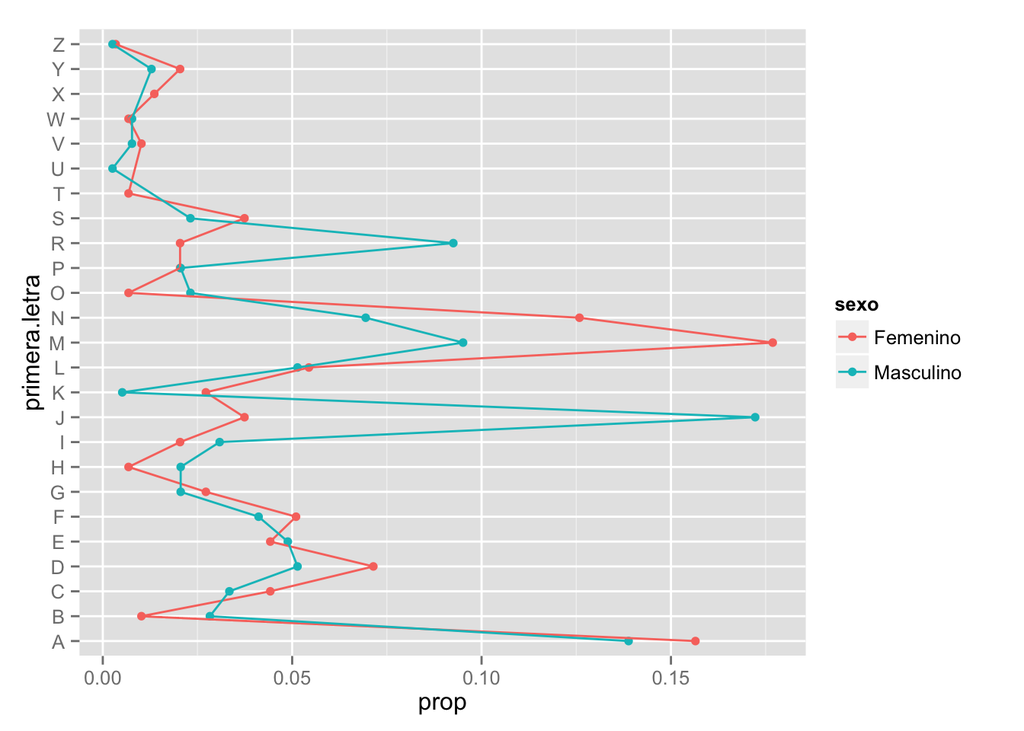

```r
library(ggplot2)
ggplot(letras.iniciales, aes(x=primera.letra, y=prop, colour=sexo, group=sexo)) +
   geom_point() + geom_line() + coord_flip()
```

¿O por nivel socioeconómico?